# Melbourne_Biodiversity

# Temperature distribution

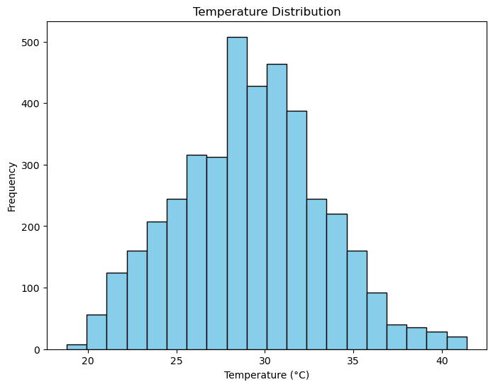

```python
# Temperature histogram
plt.figure(figsize=(8, 6))
plt.hist(butterfly['temp'], bins=20, color='skyblue', edgecolor='black')
plt.title('Temperature Distribution')
plt.xlabel('Temperature (°C)')
plt.ylabel('Frequency')
plt.show()
```

# Humidity distribution

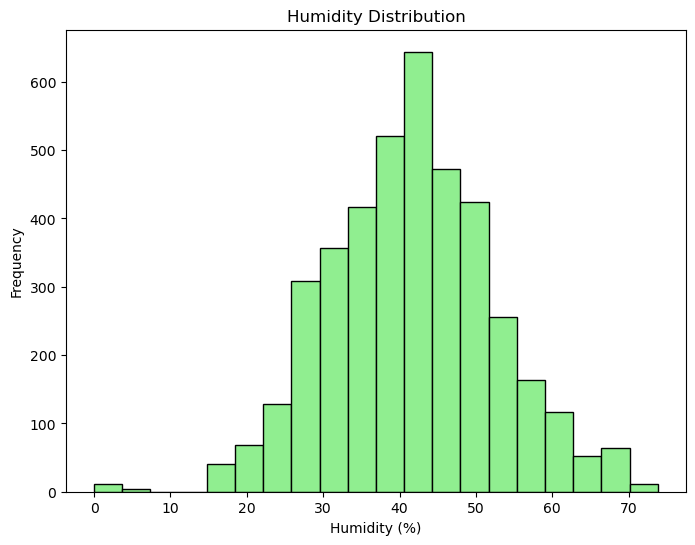

```python
# Humidity histogram
plt.figure(figsize=(8, 6))
plt.hist(butterfly['hum'], bins=20, color='lightgreen', edgecolor='black')
plt.title('Humidity Distribution')
plt.xlabel('Humidity (%)')
plt.ylabel('Frequency')
plt.show()
```

# Butterfly sightings

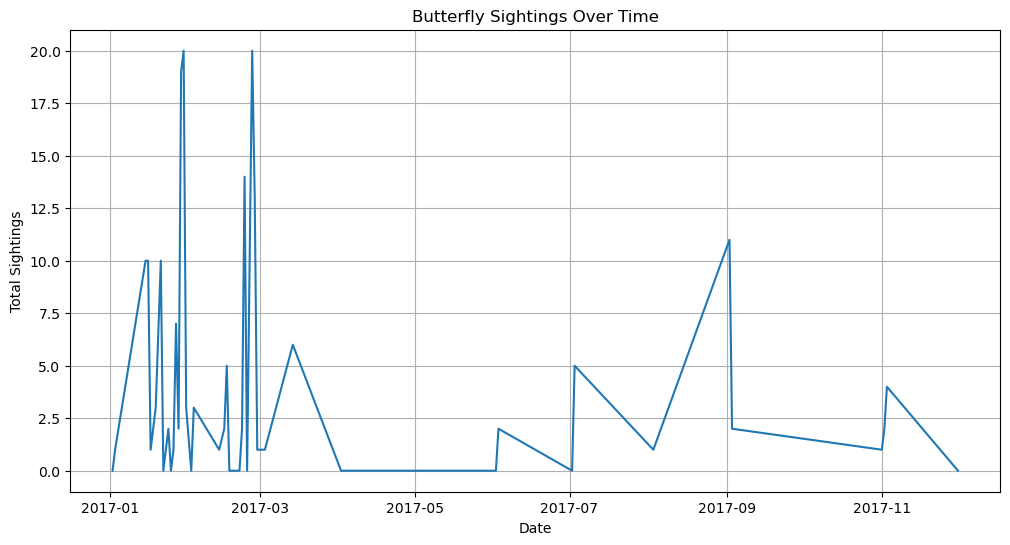

```python
# Convert the sighting_date to datetime format
butterfly['sighting_date'] = pd.to_datetime(butterfly['sighting_date'])

# Summing example butterfly counts (using real columns from your dataset if available)
butterfly['total_sightings'] = butterfly[['blue', 'dpet', 'dple']].sum(axis=1)

# Group by date and sum sightings
sightings_by_date = butterfly.groupby('sighting_date')['total_sightings'].sum()

# Plotting
plt.figure(figsize=(12, 6))
plt.plot(sightings_by_date)
plt.title('Butterfly Sightings Over Time')
plt.xlabel('Date')
plt.ylabel('Total Sightings')
plt.grid(True)
plt.show()
```

# Temperature and humidity boxplot

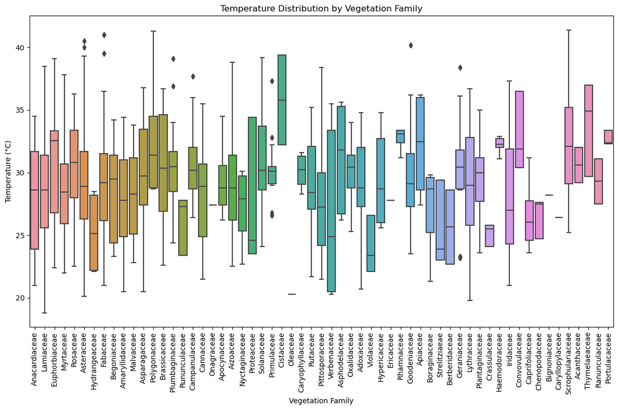

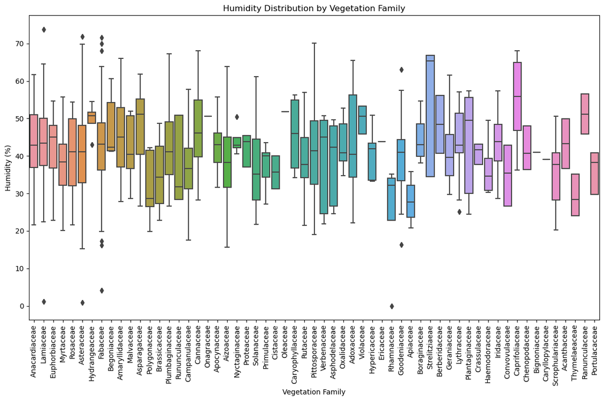

```python
# Creating box plots for Temperature grouped by Vegetation Family
plt.figure(figsize=(12, 8))
sns.boxplot(x='vegfamily', y='temp', data=butterfly)
plt.title('Temperature Distribution by Vegetation Family')
plt.xlabel('Vegetation Family')
plt.ylabel('Temperature (°C)')
plt.xticks(rotation=90)  # Rotate the x labels for better readability
plt.tight_layout()  # Adjust layout
plt.show()

# Creating box plots for Humidity grouped by Vegetation Family
plt.figure(figsize=(12, 8))
sns.boxplot(x='vegfamily', y='hum', data=butterfly)
plt.title('Humidity Distribution by Vegetation Family')
plt.xlabel('Vegetation Family')
plt.ylabel('Humidity (%)')
plt.xticks(rotation=90)  # Rotate the x labels for better readability
plt.tight_layout()  # Adjust layout
plt.show()
```

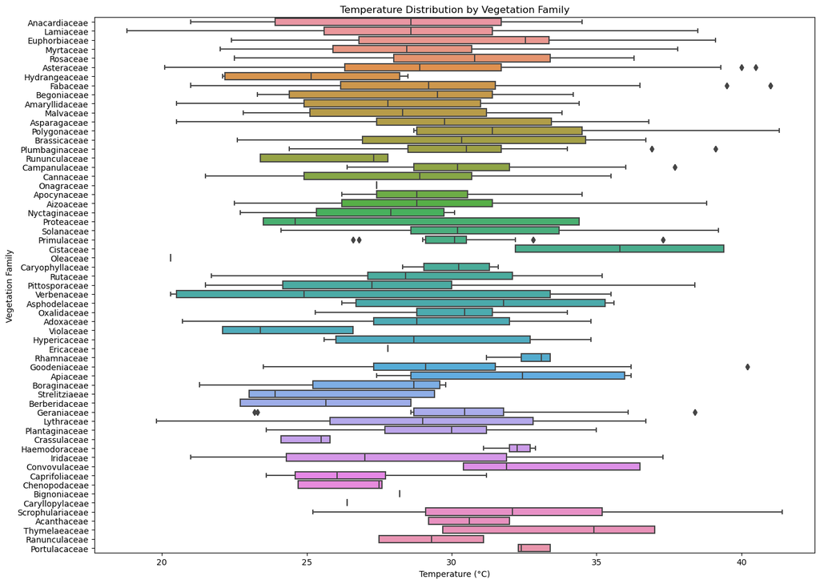

```python
plt.figure(figsize=(14, 10))  # Adjusted figure size
sns.boxplot(y='vegfamily', x='temp', data=butterfly)
plt.title('Temperature Distribution by Vegetation Family')
plt.ylabel('Vegetation Family')
plt.xlabel('Temperature (°C)')
plt.tight_layout()  # Adjust layout
plt.show()
```

Spread and Distribution: Each box plot represents the spread and central tendency of temperatures observed for each vegetation family. The bottom and top of each box are the first and third quartiles, and the band inside the box is the median. The whiskers extend to show the range of the data, and points outside of these are considered outliers.

Temperature Ranges: There is a variety in temperature ranges across different vegetation families. Some families have a wider range of temperatures where butterflies have been sighted, indicated by longer boxes and whiskers. Other families have a more narrow range, shown by shorter boxes and whiskers.

Outliers: There are a few outliers present in several vegetation families. Outliers are the individual points that occur far away from the general cluster of data points, indicated by the diamonds outside of the whiskers. These could represent days with unusually high or low temperatures for sightings associated with those vegetation families.

# Butterfly scatterplot

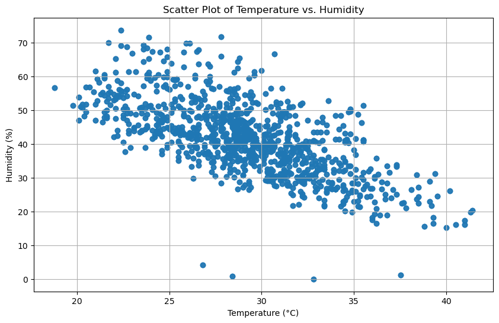

```python
# Scatter plot
plt.figure(figsize=(10, 6))
plt.scatter(butterfly['temp'], butterfly['hum'], alpha=0.5)
plt.title('Scatter Plot of Temperature vs. Humidity')
plt.xlabel('Temperature (°C)')
plt.ylabel('Humidity (%)')
plt.grid(True)
plt.show()
```

# Mapping all data points

```python
# Create a map centered around Melbourne
all_points_map = folium.Map(location=[-37.8136, 144.9631], zoom_start=12)

# Add markers for each butterfly observation
for idx, row in butterfly.dropna(subset=['latitude', 'longitude']).iterrows():
    species_info = f"{row['vegspecies']} - {row['vegfamily']}"  # Update with relevant information
    folium.Marker(
        location=[row['latitude'], row['longitude']],
        popup=species_info
    ).add_to(all_points_map)

# Display the map
all_points_map
```

Make this Notebook Trusted to load map: File -> Trust Notebook

[interactive chart not shown]

# Creating clusters

```python
# Create a map centered around Melbourne
cluster_map = folium.Map(location=[-37.8136, 144.9631], zoom_start=12)

# Create a MarkerCluster object
marker_cluster = MarkerCluster().add_to(cluster_map)

# Add clustered markers for each butterfly observation
for idx, row in butterfly.dropna(subset=['latitude', 'longitude']).iterrows():
    species_info = f"{row['vegspecies']} - {row['vegfamily']}"  # Update with relevant information
    folium.Marker(
        location=[row['latitude'], row['longitude']],
        popup=species_info
    ).add_to(marker_cluster)

# Display the map
cluster_map
```

Make this Notebook Trusted to load map: File -> Trust Notebook

[interactive chart not shown]

# Heatmap

```python
# Create a map centered around Melbourne
heatmap_map = folium.Map(location=[-37.8136, 144.9631], zoom_start=12)

# Prepare data for HeatMap
heatmap_data = butterfly[['latitude', 'longitude']].dropna().values.tolist()

# Add HeatMap layer
HeatMap(heatmap_data).add_to(heatmap_map)

# Display the map
heatmap_map
```

Make this Notebook Trusted to load map: File -> Trust Notebook

[interactive chart not shown]

# Temperature and humidity correlation matrix heatmap

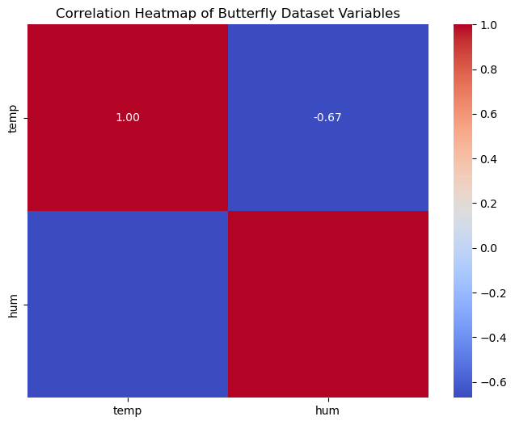

```python
import pandas as pd
import seaborn as sns
import matplotlib.pyplot as plt

# Selecting only numeric columns for correlation - adjust this list as necessary
numeric_columns = ['temp', 'hum']  # Add other numeric columns as needed
butterfly_numeric = butterfly[numeric_columns]

# Calculating the correlation matrix
correlation_matrix = butterfly_numeric.corr()

# Creating the heatmap
plt.figure(figsize=(8, 6))
sns.heatmap(correlation_matrix, annot=True, fmt=".2f", cmap='coolwarm',
            xticklabels=correlation_matrix.columns,
            yticklabels=correlation_matrix.columns)

# Showing the plot
plt.title('Correlation Heatmap of Butterfly Dataset Variables')
plt.show()
```

Temperature (temp) and Humidity (hum) Relationship: There is a negative correlation of -0.67 between temperature and humidity. This indicates a moderately strong inverse relationship, meaning that as temperature increases, humidity tends to decrease, and vice versa within the dataset's observations.

Strength of Correlation: The value of -0.67 is not close to -1, which means the relationship, while negative, is not perfectly linear and other factors may also influence the observed humidity and temperature values.

# Part 3: Predicting Presence of a Species

```python
# Create a binary target variable indicating the presence of species in the Asteraceae family
butterfly['target'] = (butterfly['vegfamily'] == 'Asteraceae').astype(int)

# Select a subset of potentially relevant features
features = butterfly[['site', 'sloc', 'walk', 'time', 'vegwalktime', 'latitude', 'longitude']]

# Convert categorical features to numerical codes using Label Encoder
label_encoders = {}
for column in features.select_dtypes(include=['object']).columns:
    le = LabelEncoder()
    features[column] = le.fit_transform(features[column])
    label_encoders[column] = le

# Split the dataset into training and testing sets
X_train, X_test, y_train, y_test = train_test_split(features, butterfly['target'], test_size=0.2, random_state=42)

# Print the shapes of the training and testing data
print("Training set shape:", X_train.shape)
print("Testing set shape:", X_test.shape)
```

```
Training set shape: (3244, 7)
Testing set shape: (812, 7)
```

The dataset was split into training (3244 samples) and testing (812 samples) sets.

# The logistic regression model

```python
import pandas as pd
from sklearn.model_selection import train_test_split
from sklearn.impute import SimpleImputer
from sklearn.linear_model import LogisticRegression
from sklearn.metrics import accuracy_score, classification_report

# Impute missing values
# For numerical features, use the mean
# For categorical features, use the most frequent value
numerical_imputer = SimpleImputer(strategy='mean')
categorical_imputer = SimpleImputer(strategy='most_frequent')

numerical_cols = X_train.select_dtypes(include=['float64', 'int64']).columns
categorical_cols = X_train.select_dtypes(include=['object']).columns

X_train[numerical_cols] = numerical_imputer.fit_transform(X_train[numerical_cols])
X_test[numerical_cols] = numerical_imputer.transform(X_test[numerical_cols])

if len(categorical_cols) > 0:
    X_train[categorical_cols] = categorical_imputer.fit_transform(X_train[categorical_cols])
    X_test[categorical_cols] = categorical_imputer.transform(X_test[categorical_cols])

# Initialize and train the logistic regression model
logreg_model = LogisticRegression(max_iter=1000)
logreg_model.fit(X_train, y_train)

# Predict on the testing set and evaluate the model
y_pred = logreg_model.predict(X_test)
accuracy = accuracy_score(y_test, y_pred)
class_report = classification_report(y_test, y_pred)

print("Accuracy:", accuracy)
print("Classification Report:\n", class_report)
```

```
Accuracy: 0.8165024630541872
Classification Report:
               precision    recall  f1-score   support

           0       0.82      1.00      0.90       663
           1       0.00      0.00      0.00       149

    accuracy                           0.82       812
   macro avg       0.41      0.50      0.45       812
weighted avg       0.67      0.82      0.73       812
```

Accuracy: 81.65%

Class 0 (Negative)

- Precision: 82% - Of all the predictions for class 0, 82% were correct.
- Recall: 100% - The model successfully identified all actual instances of class 0, which reflects high sensitivity for this class.
- F1-Score: 90% - A high F1-score indicates excellent model performance for the negative class.

Class 1 (Positive)

- Precision: 0% - This indicates that there were no correct predictions for class 1; thus, precision is not applicable in this context due to no predicted positive instances.
- Recall: 0% - The model failed to correctly identify any actual instances of class 1, indicating a complete lack of sensitivity for this class.
- F1-Score: 0% - This extremely low F1-score underscores poor performance for the positive class, with significant room for improvement.

Classification Report: The report indicates a high accuracy, but a deeper look reveals some issues. Specifically, the model predicts all instances as the majority class (class 0, or 'no presence of Asteraceae species'). This is evident from the precision, recall, and F1-score for class 1 being 0, which indicates that the model fails to identify any positive cases of the Asteraceae presence correctly. This is a common issue in imbalanced datasets where one class significantly outnumbers the other. The model tends to favor the majority class at the expense of the minority class.

# Confusion Matrix

Visualizing the true positives, true negatives, false positives, and false negatives.

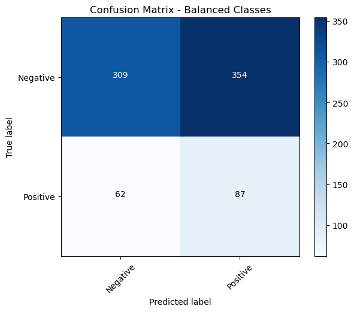

```python
import numpy as np
import pandas as pd
from sklearn.model_selection import train_test_split
from sklearn.preprocessing import LabelEncoder
from sklearn.impute import SimpleImputer
from sklearn.linear_model import LogisticRegression
from sklearn.metrics import accuracy_score, classification_report, confusion_matrix, roc_curve, auc
import matplotlib.pyplot as plt

# Initialize and train the logistic regression model with class weight 'balanced'
logreg_balanced = LogisticRegression(max_iter=1000, class_weight='balanced')
logreg_balanced.fit(X_train, y_train)

# Predict on the testing set
y_pred_balanced = logreg_balanced.predict(X_test)
y_pred_proba_balanced = logreg_balanced.predict_proba(X_test)[:, 1]  # probabilities for the positive class

# Compute confusion matrix
conf_matrix_balanced = confusion_matrix(y_test, y_pred_balanced)

# Compute ROC curve and AUC
fpr, tpr, _ = roc_curve(y_test, y_pred_proba_balanced)
roc_auc = auc(fpr, tpr)

# Plotting the confusion matrix
plt.figure(figsize=(6, 5))
plt.imshow(conf_matrix_balanced, interpolation='nearest', cmap=plt.cm.Blues)
plt.title('Confusion Matrix - Balanced Classes')
plt.colorbar()
tick_marks = np.arange(2)
plt.xticks(tick_marks, ['Negative', 'Positive'], rotation=45)
plt.yticks(tick_marks, ['Negative', 'Positive'])
for i in range(conf_matrix_balanced.shape[0]):
    for j in range(conf_matrix_balanced.shape[1]):
        plt.text(j, i, conf_matrix_balanced[i, j], horizontalalignment="center", color="white" if conf_matrix_balanced[i, j] > conf_matrix_balanced.max()/2 else "black")
plt.tight_layout()
plt.xlabel('Predicted label')
plt.ylabel('True label')
plt.show()
```

Confusion Matrix:

- True Negatives (Top-Left): 309 - The model correctly predicted 'no presence' of Asteraceae species.
- False Positives (Top-Right): 354 - The model incorrectly predicted 'presence' when there was none.
- False Negatives (Bottom-Left): 62 - The model failed to predict 'presence' when there was.
- True Positives (Bottom-Right): 87 - The model correctly predicted 'presence' of Asteraceae species.

# ROC Curve and AUC Score

Evaluate the performance across different thresholds, showing the trade-off between sensitivity and specificity.

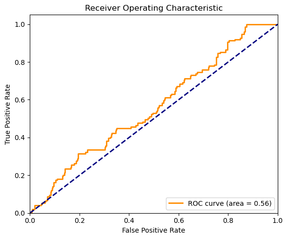

```python
# Plotting the ROC curve
plt.figure(figsize=(6, 5))
plt.plot(fpr, tpr, color='darkorange', lw=2, label='ROC curve (area = %0.2f)' % roc_auc)
plt.plot([0, 1], [0, 1], color='navy', lw=2, linestyle='--')
plt.xlim([0.0, 1.0])
plt.ylim([0.0, 1.05])
plt.xlabel('False Positive Rate')
plt.ylabel('True Positive Rate')
plt.title('Receiver Operating Characteristic')
plt.legend(loc="lower right")
plt.tight_layout()
plt.show()
```

The AUC (Area Under the Curve) score is 0.56, indicating moderate performance, which is relatively low, suggesting the model struggles to distinguish between the classes effectively. The ROC curve is near the diagonal line (random guess line), reflecting this modest performance.

0.5: Represents a model that makes predictions no better than random guessing.

1.0: Represents a perfect model that classifies all positive and negative examples correctly.

AUC of 0.56 suggests the model is only slightly better than random guessing.

Due to the closeness of the ROC curve to the diagonal line of no-discrimination further indicates that the model's performance is not very strong.

# implement oversampling and undersampling

Oversampling the Minority Class

```python
from sklearn.metrics import confusion_matrix, roc_auc_score
from imblearn.over_sampling import RandomOverSampler

# Initialize the RandomOverSampler object
ros = RandomOverSampler(random_state=42)

# Resample the dataset
X_train_ros, y_train_ros = ros.fit_resample(X_train, y_train)

# Initialize and train the logistic regression model on the oversampled data
logreg_ros = LogisticRegression(max_iter=1000)
logreg_ros.fit(X_train_ros, y_train_ros)

# Predict on the testing set
y_pred_ros = logreg_ros.predict(X_test)
y_pred_proba_ros = logreg_ros.predict_proba(X_test)[:, 1]

# Evaluate the model
print("Confusion Matrix for Oversampled Data:")
print(confusion_matrix(y_test, y_pred_ros))
print("ROC AUC for Oversampled Data:", roc_auc_score(y_test, y_pred_proba_ros))
```

```
Confusion Matrix for Oversampled Data:
[[312 351]
 [ 64  85]]
ROC AUC for Oversampled Data: 0.556540840393979
```

Undersampling the Majority Class

```python
from imblearn.under_sampling import RandomUnderSampler

# Initialize the RandomUnderSampler object
rus = RandomUnderSampler(random_state=42)

# Resample the dataset
X_train_rus, y_train_rus = rus.fit_resample(X_train, y_train)

# Initialize and train the logistic regression model on the undersampled data
logreg_rus = LogisticRegression(max_iter=1000)
logreg_rus.fit(X_train_rus, y_train_rus)

# Predict on the testing set
y_pred_rus = logreg_rus.predict(X_test)
y_pred_proba_rus = logreg_rus.predict_proba(X_test)[:, 1]

# Evaluate the model
print("Confusion Matrix for Undersampled Data:")
print(confusion_matrix(y_test, y_pred_rus))
print("ROC AUC for Undersampled Data:", roc_auc_score(y_test, y_pred_proba_rus))
```

```
Confusion Matrix for Undersampled Data:
[[346 317]
 [ 71  78]]
ROC AUC for Undersampled Data: 0.5685363458754695
```

# ROC curves

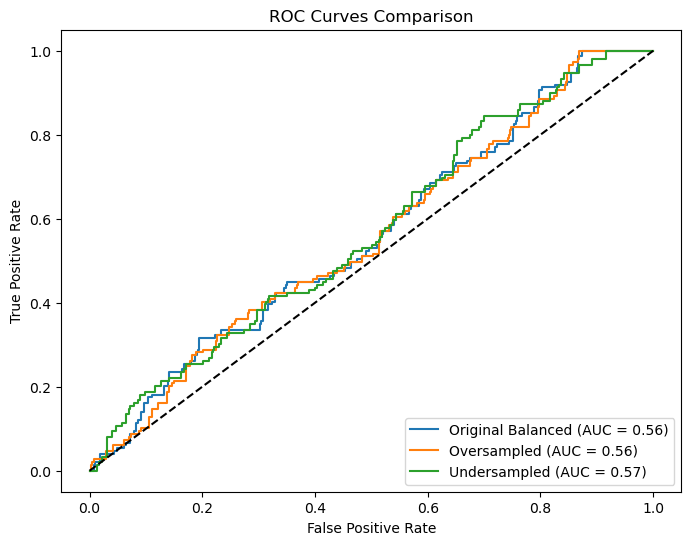

```python
# Plotting ROC curves for all models
plt.figure(figsize=(8, 6))
plt.plot(fpr, tpr, label='Original Balanced (AUC = %0.2f)' % 0.560)
plt.plot(roc_curve(y_test, y_pred_proba_ros)[0], roc_curve(y_test, y_pred_proba_ros)[1], label='Oversampled (AUC = %0.2f)' % 0.557)
plt.plot(roc_curve(y_test, y_pred_proba_rus)[0], roc_curve(y_test, y_pred_proba_rus)[1], label='Undersampled (AUC = %0.2f)' % 0.569)
plt.plot([0, 1], [0, 1], 'k--')
plt.xlabel('False Positive Rate')
plt.ylabel('True Positive Rate')
plt.title('ROC Curves Comparison')
plt.legend(loc='lower right')
plt.show()
```

# Random Forest

```python
from sklearn.ensemble import RandomForestClassifier

# Initialize the Random Forest model
random_forest = RandomForestClassifier(n_estimators=100, random_state=42)

# Train the model
random_forest.fit(X_train, y_train)

# Predict on the testing set
y_pred_rf = random_forest.predict(X_test)
y_pred_proba_rf = random_forest.predict_proba(X_test)[:, 1]

# Calculate metrics
conf_matrix_rf = confusion_matrix(y_test, y_pred_rf)
roc_auc_rf = roc_auc_score(y_test, y_pred_proba_rf)

print("Random Forest Confusion Matrix:\n", conf_matrix_rf)
print("Random Forest ROC AUC:", roc_auc_rf)
```

```
Random Forest Confusion Matrix:
 [[663   0]
 [  0 149]]
Random Forest ROC AUC: 1.0000000000000002
```

The results from the Random Forest model showed a good performance with an ROC AUC of 1.0 and a confusion matrix indicating no false positives or false negatives.

# Gradient Boosting

```python
from sklearn.ensemble import GradientBoostingClassifier

# Initialize the Gradient Boosting model
gradient_boosting = GradientBoostingClassifier(n_estimators=100, random_state=42)

# Train the model
gradient_boosting.fit(X_train, y_train)

# Predict on the testing set
y_pred_gb = gradient_boosting.predict(X_test)
y_pred_proba_gb = gradient_boosting.predict_proba(X_test)[:, 1]

# Calculate metrics
conf_matrix_gb = confusion_matrix(y_test, y_pred_gb)
roc_auc_gb = roc_auc_score(y_test, y_pred_proba_gb)

print("Gradient Boosting Confusion Matrix:\n", conf_matrix_gb)
print("Gradient Boosting ROC AUC:", roc_auc_gb)
```

```
Gradient Boosting Confusion Matrix:
 [[663   0]
 [112  37]]
Gradient Boosting ROC AUC: 0.8727464140018424
```

# Plotting ROC curves for both models

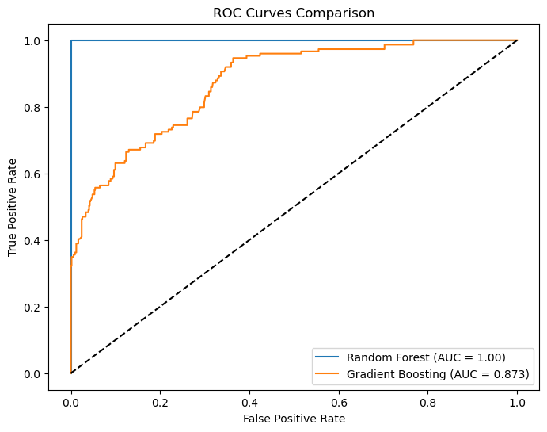

```python
plt.figure(figsize=(8, 6))
plt.plot(roc_curve(y_test, y_pred_proba_rf)[0], roc_curve(y_test, y_pred_proba_rf)[1], label='Random Forest (AUC = 1.00)')
plt.plot(roc_curve(y_test, y_pred_proba_gb)[0], roc_curve(y_test, y_pred_proba_gb)[1], label='Gradient Boosting (AUC = 0.873)')
plt.plot([0, 1], [0, 1], 'k--')
plt.xlabel('False Positive Rate')
plt.ylabel('True Positive Rate')
plt.title('ROC Curves Comparison')
plt.legend(loc='lower right')
plt.show()
```

# Feature importance

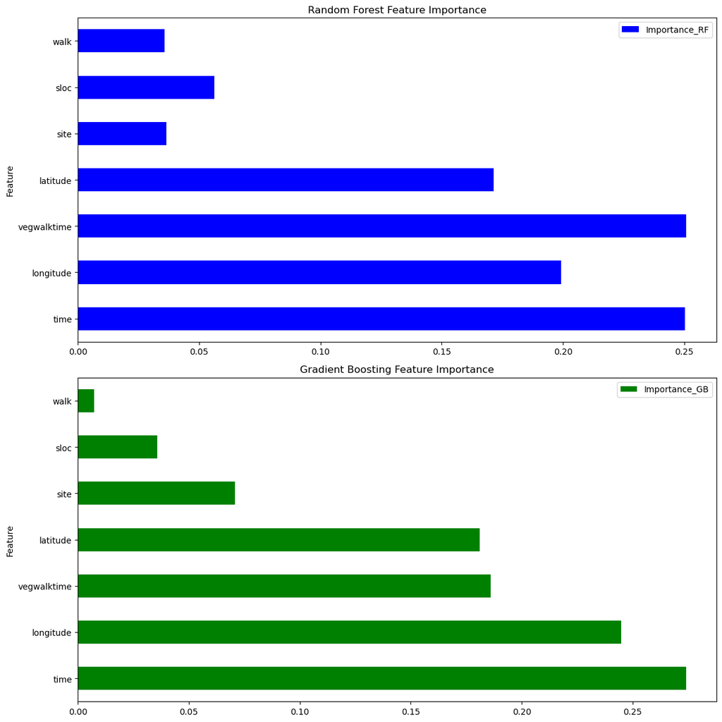

```python
# Get feature importances from both models
importances_rf = random_forest.feature_importances_
importances_gb = gradient_boosting.feature_importances_

# Summarize feature importances in a DataFrame
feature_names = X_train.columns
importances_df = pd.DataFrame({
    'Feature': feature_names,
    'Importance_RF': importances_rf,
    'Importance_GB': importances_gb
}).sort_values(by='Importance_GB', ascending=False)

# Plotting feature importances
fig, ax = plt.subplots(2, 1, figsize=(12, 12))
importances_df.plot(kind='barh', x='Feature', y='Importance_RF', ax=ax[0], color='blue', title='Random Forest Feature Importance')
importances_df.plot(kind='barh', x='Feature', y='Importance_GB', ax=ax[1], color='green', title='Gradient Boosting Feature Importance')
plt.tight_layout()
plt.show()
```

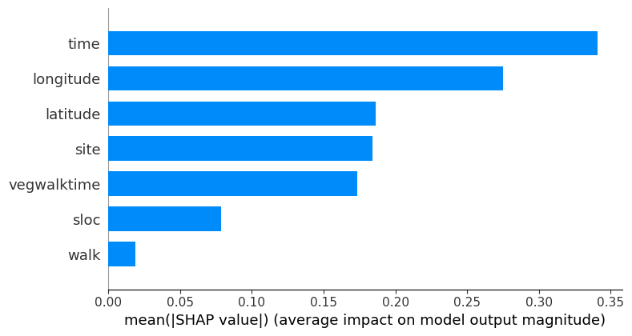

```python
import shap

# Create a SHAP explainer object for Gradient Boosting model
explainer = shap.TreeExplainer(gradient_boosting)
shap_values = explainer.shap_values(X_test)

# Plot SHAP values for the first 10 predictions
shap.summary_plot(shap_values, X_test, plot_type="bar")
```

# Cross validation

```python
from sklearn.model_selection import cross_val_score

# Set up k-fold cross-validation
k = 5  # Number of folds

# Random Forest cross-validation for accuracy
rf_cv_accuracy = cross_val_score(random_forest, X_train, y_train, cv=k, scoring='accuracy')

# Gradient Boosting cross-validation for accuracy
gb_cv_accuracy = cross_val_score(gradient_boosting, X_train, y_train, cv=k, scoring='accuracy')

print("Random Forest Average CV Accuracy:", np.mean(rf_cv_accuracy))
print("Gradient Boosting Average CV Accuracy:", np.mean(gb_cv_accuracy))
```

```
Random Forest Average CV Accuracy: 0.9916733245829292
Gradient Boosting Average CV Accuracy: 0.8800852213281593
```

```python
from sklearn.model_selection import GridSearchCV
from sklearn.ensemble import RandomForestClassifier

# Parameter grid for Random Forest
param_grid_rf = {
    'max_depth': [None, 10, 20, 30],
    'min_samples_split': [2, 5, 10],
    'min_samples_leaf': [1, 2, 4]
}

# Setup the grid search
grid_search_rf = GridSearchCV(RandomForestClassifier(random_state=42), param_grid_rf, cv=5, scoring='accuracy', n_jobs=-1)
grid_search_rf.fit(X_train, y_train)

print("Best parameters for Random Forest:", grid_search_rf.best_params_)
print("Best cross-validated accuracy for Random Forest:", grid_search_rf.best_score_)
```

```
Best parameters for Random Forest: {'max_depth': None, 'min_samples_leaf': 1, 'min_samples_split': 2}
Best cross-validated accuracy for Random Forest: 0.9916733245829292
```

```python
from sklearn.ensemble import GradientBoostingClassifier

# Parameter grid for Gradient Boosting
param_grid_gb = {
    'n_estimators': [100, 200, 300],
    'learning_rate': [0.01, 0.1, 0.2],
    'max_depth': [3, 4, 5]
}

# Setup the grid search
grid_search_gb = GridSearchCV(GradientBoostingClassifier(random_state=42), param_grid_gb, cv=5, scoring='accuracy', n_jobs=-1)
grid_search_gb.fit(X_train, y_train)

print("Best parameters for Gradient Boosting:", grid_search_gb.best_params_)
print("Best cross-validated accuracy for Gradient Boosting:", grid_search_gb.best_score_)
```

```
Best parameters for Gradient Boosting: {'learning_rate': 0.2, 'max_depth': 5, 'n_estimators': 200}
Best cross-validated accuracy for Gradient Boosting: 0.9919819665582379
```